# To Tidymodel or not to Tidymodel, that this the question

2023-10-26

## Table of Contents

## What is(/are) ‘Tidymodels’

“Tidymodels is a collection of R packages and a framework for modeling and machine learning that follows the principles of tidy data and integrates seamlessly with the tidyverse ecosystem.

It was developed to provide a consistent and organized way to perform machine learning tasks in R, making it easier for data scientists and analysts to build, evaluate, and deploy predictive models.”

## Remember this?

```r
model <- lm(outcome ~ predictor1 + predictor2 + predictor3 + control1 + control2, data=data)
summary(model)
```

- Base R equivalent: ‘R formula’
  - Example: `lm(y ~ x1 + x2, data)`
- Uses old R syntax
  - Example: `aov(y ~ x * group, data)`
- Each model different syntax - can’t swap in / out
  - Example: Different functions for `glm()`, `lm()`, `rpart()`, etc.
- Preprocessing a whole separate data wrangling exercise
- No standardized framework for evaluation & tuning
- Outputs are ugly + not always a dataframe

What if you’d realized you’d been barking up the wrong tree all this time and wanted to run a different model?

- Decision Trees (`rpart` or `randomForest`)
- Poisson Regression
- Neural net (`keras`)
- Time series

## R’s strength is also its greatest weakness…

One of the strengths of R is that it encourages developers to create a user interface that fits their needs. As an example, here are three common methods for creating a scatter plot of two numeric variables in a data frame called `plot_data`:

## Different Plotting Methods in R

## using Base R plot

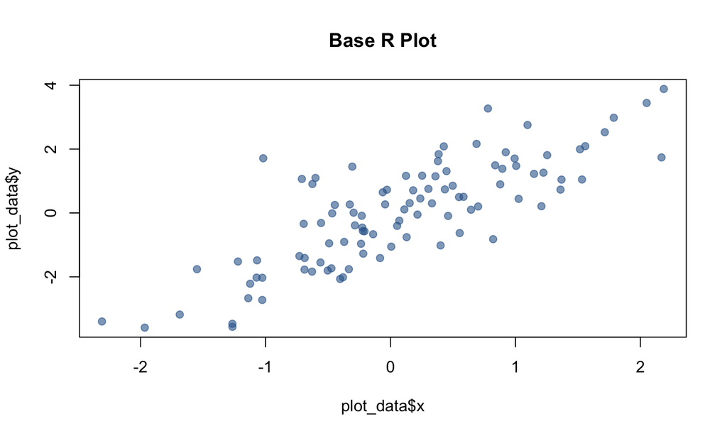

```r
plot(plot_data$x, plot_data$y, main="Base R Plot", pch=19, col=rgb(0.2,0.4,0.6,0.6))
```

## Using Lattice

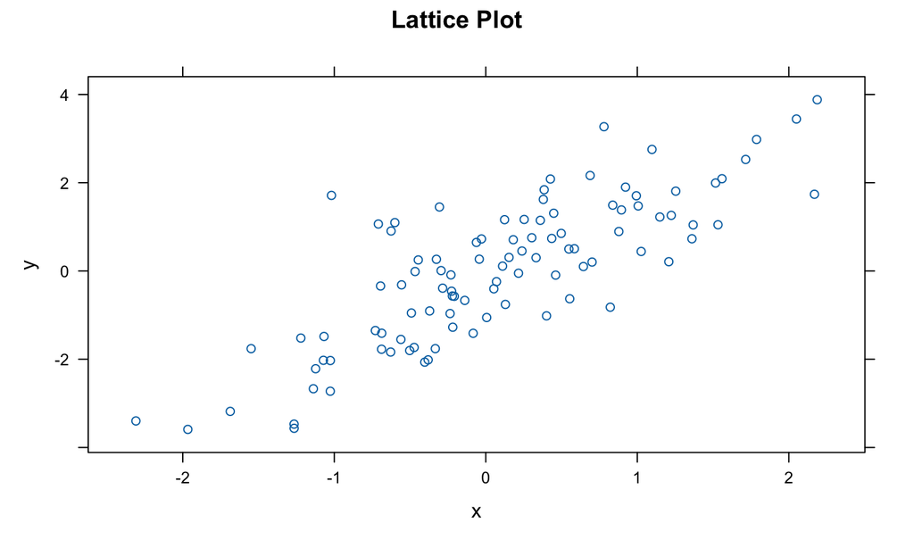

```r
print(xyplot(y ~ x, data = plot_data, main="Lattice Plot"))
```

## Using ggplot2

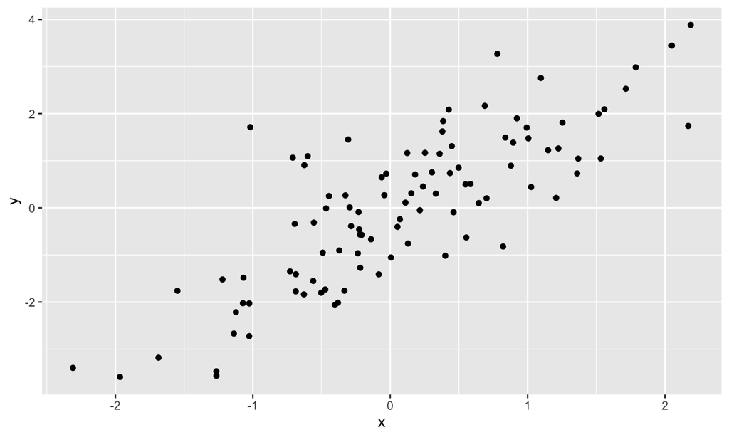

```r
ggplot(plot_data, aes(x = x, y = y)) + geom_point()
```

## break

In these three cases, separate groups of developers devised three distinct interfaces for the same task. Each has advantages and disadvantages.

In comparison, the Python Developer’s Guide espouses the notion that, when approaching a problem: “There should be one – and preferably only one – obvious way to do it.”